# Test_Github_R

Download all the packages that are needed for the code to run

```r
# Download packages needed:
# DESeq for analysis of differential expression
if (!requireNamespace("BiocManager", quietly = TRUE))
  install.packages("BiocManager")

BiocManager::install("DESeq")
install.packages("venneuler")
install.packages("VennDiagram")
```

The packages are then loaded using library()

```r
library('DESeq')
library(stringr) # Needed to extract data of interest from counts from Artremis
library(dplyr) # allows row comparisons
library(VennDiagram)
library(RColorBrewer)
```

```r
setwd("~/Johannas_Rcode")
```

```
The working directory was changed to /home/student10/Johannas_Rcode inside a notebook chunk. The working directory will be reset when the chunk is finished running. Use the knitr root.dir option in the setup chunk to change the working directory for notebook chunks.
```

```r
# Download the files
raw_0h = read.table("~/Johannas_Rcode/results/mapping_results/counts_values_0h.txt", sep = "\t", header = TRUE, row.names = 1)
raw_30min = read.table("~/Johannas_Rcode/results/mapping_results/counts_values_30min.txt", sep = "\t", header = TRUE, row.names = 1)
raw_6h = read.table("~/Johannas_Rcode/results/mapping_results/counts_values_6h.txt", sep = "\t", header = TRUE, row.names = 1)
raw_24h = read.table("~/Johannas_Rcode/results/mapping_results/counts_values_24h.txt", sep = "\t", header = TRUE, row.names = 1)
```

When doing this import, a data.frame consisting of the sense, antisense and total counts is generated. Since we are only interested in the total counts, which is the last “word” in a string, we can extract this part using the “stringr” package. Followed by this, we set the row and colnames to the same as before, and merge data from all time points with that of the 0hr samples. We then remove the total counts to not have to many things saved in our environment.

```r
# Extracting only total counts

# for 0h counts
counts_values_0h_total =
  data.frame(as.integer(str_extract(raw_0h[-1,]$ERR405224.sorted.bam,"\\w+$")),
             as.integer(str_extract(raw_0h[-1,]$ERR405225.sorted.bam,"\\w+$")),
             as.integer(str_extract(raw_0h[-1,]$ERR405226.sorted.bam, "\\w+$")))

colnames(counts_values_0h_total) = colnames(raw_0h[1:3])
rownames(counts_values_0h_total) = rownames(raw_0h[-1,])

# for 30 min
counts_values_30min_total =
  data.frame(as.integer(str_extract(raw_30min[-1,]$ERR405227.sorted.bam,"\\w+$")),
             as.integer(str_extract(raw_30min[-1,]$ERR405228.sorted.bam,"\\w+$")),
             as.integer(str_extract(raw_30min[-1,]$ERR405229.sorted.bam, "\\w+$")))
# the raw_0h[-1,] removes the row giving the "total" header for each column in 30 min sample
colnames(counts_values_30min_total) = colnames(raw_30min[1:3])
rownames(counts_values_30min_total) = rownames(raw_30min[-1,])

# for 6h
counts_values_6h_total =
  data.frame(as.integer(str_extract(raw_6h[-1,]$mapped_ERR405230.sorted.bam,"\\w+$")),
             as.integer(str_extract(raw_6h[-1,]$mapped_ERR405231.sorted.bam,"\\w+$")),
             as.integer(str_extract(raw_6h[-1,]$mapped_ERR405232.sorted.bam, "\\w+$")))

colnames(counts_values_6h_total) = colnames(raw_6h[1:3])
rownames(counts_values_6h_total) = rownames(raw_6h[-1,])

# for 24h
counts_values_24h_total =
  data.frame(as.integer(str_extract(raw_24h[-1,]$mapped_ERR405233.sorted.bam,"\\w+$")),
             as.integer(str_extract(raw_24h[-1,]$mapped_ERR405234.sorted.bam,"\\w+$")),
             as.integer(str_extract(raw_24h[-1,]$mapped_ERR405235.sorted.bam, "\\w+$")))

colnames(counts_values_24h_total) = colnames(raw_24h[1:3])
rownames(counts_values_24h_total) = rownames(raw_24h[-1,])

# Merge the 0h controll with the counts for other time points
raw_counts_30min_0h = data.frame(counts_values_0h_total, counts_values_30min_total)
raw_counts_6h_0h = data.frame(counts_values_0h_total, counts_values_6h_total)
raw_counts_24h_0h = data.frame(counts_values_0h_total, counts_values_24h_total)
rm(counts_values_30min_total, counts_values_6h_total, counts_values_24h_total)
```

Following the installation, the DESeq analysis is run. To do so, we specify what columns correspond to a given condition, i.e. compare data from time 0 and time 0.5h samples. The procedure of doing the DEseq is taken from the vignette(“DESeq”) file available at: http://15.236.44.5:8787/files/R/x86_64-pc-linux-gnu-library/3.6/DESeq/doc/DESeq.pdf

```r
condition_30min = factor(c("0h","0h","0h","0.5h","0.5h","0.5h"))
condition_6h = factor(c("0h","0h","0h","6h","6h","6h"))
condition_24h = factor(c("0h","0h","0h","24h","24h","24h"))

count_ds_30min = newCountDataSet(countData = raw_counts_30min_0h, condition_30min)
count_ds_6h = newCountDataSet(countData = raw_counts_6h_0h, condition_6h)
count_ds_24h = newCountDataSet(countData = raw_counts_24h_0h, condition_24h)
```

```r
# For the 30 min
count_ds_30min = estimateSizeFactors(count_ds_30min)
sizeFactors(count_ds_30min)
```

```
ERR405224.sorted.bam ERR405225.sorted.bam ERR405226.sorted.bam
           1.3865567            1.2672982            0.6525154
ERR405227.sorted.bam ERR405228.sorted.bam ERR405229.sorted.bam
           0.9701831            1.1700170            0.7623811
```

```r
head(counts(count_ds_30min, normalized=TRUE))
```

```
     ERR405224.sorted.bam ERR405225.sorted.bam ERR405226.sorted.bam
gltD             124.7695             125.4638             140.9928
gltB             390.8964             439.5177             406.1207
gltA           60460.5642           66451.6030           62948.7033
yqeF            1034.9378            1020.2807            1058.9788
mesJ             491.1447             508.9568             530.2557
phoU             433.4478             367.7114             375.4701
     ERR405227.sorted.bam ERR405228.sorted.bam ERR405229.sorted.bam
gltD             177.2861             164.1002             208.5571
gltB             404.0475             322.2175             362.0237
gltA           77340.0428           87010.7022           63474.8198
yqeF            1358.5065            1397.4156             939.1629
mesJ             381.3713             452.9849             413.1792
phoU             523.6125             435.0364             592.8794
```

```r
count_ds_30min = estimateDispersions(count_ds_30min)

# For 6h
count_ds_6h = estimateSizeFactors(count_ds_6h)
sizeFactors(count_ds_6h)
```

```
       ERR405224.sorted.bam        ERR405225.sorted.bam
                  1.6661891                   1.5154161
       ERR405226.sorted.bam mapped_ERR405230.sorted.bam
                  0.7840292                   0.9034004
mapped_ERR405231.sorted.bam mapped_ERR405232.sorted.bam
                  1.1377303                   0.5002054
```

```r
head(counts(count_ds_6h, normalized=TRUE))
```

```
     ERR405224.sorted.bam ERR405225.sorted.bam ERR405226.sorted.bam
gltD             103.8298             104.9217             117.3426
gltB             325.2932             367.5558             337.9976
gltA           50313.6166           55571.5350           52389.6282
yqeF             861.2468             853.2310             881.3447
mesJ             408.7171             425.6257             441.3101
phoU             360.7034             307.5063             312.4883
     mapped_ERR405230.sorted.bam mapped_ERR405231.sorted.bam
gltD                    148.3285                    147.6624
gltB                    322.1163                    312.9037
gltA                  57235.9693                  63789.2830
yqeF                    697.3652                    830.6011
mesJ                    384.1043                    365.6403
phoU                    502.5457                    433.3189
     mapped_ERR405232.sorted.bam
gltD                    169.9302
gltB                    303.8752
gltA                  50819.1261
yqeF                    589.7578
mesJ                    411.8308
phoU                    561.7693
```

```r
count_ds_6h = estimateDispersions(count_ds_6h)

# For 24h
count_ds_24h = estimateSizeFactors(count_ds_24h)
sizeFactors(count_ds_24h)
```

```
       ERR405224.sorted.bam        ERR405225.sorted.bam
                  2.0250477                   1.8441421
       ERR405226.sorted.bam mapped_ERR405233.sorted.bam
                  0.9476914                   0.5913396
mapped_ERR405234.sorted.bam mapped_ERR405235.sorted.bam
                  0.8549554                   0.5611626
```

```r
head(counts(count_ds_24h, normalized=TRUE))
```

```
     ERR405224.sorted.bam ERR405225.sorted.bam ERR405226.sorted.bam
gltD             85.43009             86.21895             97.07801
gltB            267.64801            302.03746            279.62689
gltA          41397.54292          45665.67877          43342.16786
yqeF            708.62528            701.13903            729.14030
mesJ            336.28837            349.75613            365.09775
phoU            296.78313            252.69203            258.52297
     mapped_ERR405233.sorted.bam mapped_ERR405234.sorted.bam
gltD                    109.9199                     72.5184
gltB                    262.1167                    260.8323
gltA                  63623.3354                  62252.3702
yqeF                    952.0755                   1063.2134
mesJ                    287.4828                    302.9398
phoU                    304.3936                    314.6363
     mapped_ERR405235.sorted.bam
gltD                    155.0353
gltB                    263.7382
gltA                  50796.3320
yqeF                    598.7570
mesJ                    222.7519
phoU                    358.1850
```

```r
count_ds_24h = estimateDispersions(count_ds_24h)
#str(fitInfo(count_ds_6h))
#plotDispEsts(count_ds_6h) # Gives the fitted dispersion vs normalized mean to see fit
```

To compare our data from the DE analysis, the results command is used with a “nbinomTest” to caluclate log-changes etc. This gives an output in the following form: id - feature identifier baseMean - mean normalised counts, averaged over all samples from both conditions baseMeanA - mean normalised counts from condition A (0hr) baseMeanB - mean normalised counts from condition B (given timepoint) foldChange - fold change from condition A to B log2FoldChange - the logarithm (to basis 2) of the fold change pval - p value for the statistical significance of this change padj - p value adjusted for multiple testing with the Benjamini-Hochberg procedure (see the R function p.adjust), which controls false discovery rate (FDR)

```r
#modelled_data = DESeq(modelled_data)
result_30min = nbinomTest(count_ds_30min, "0h", "0.5h" ) # Calculate logFC + p
result_30min = data.frame(result_30min, row.names = 1) # set gene names as row names in the results table

result_6h = nbinomTest(count_ds_6h, "0h", "6h" ) # Calculate logFC + p
result_6h = data.frame(result_6h, row.names = 1) # set gene names as row names in the results table

result_24h = nbinomTest(count_ds_24h, "0h", "24h" ) # Calculate logFC + p
result_24h = data.frame(result_24h, row.names = 1)
```

```r
print(number_DE)
```

```
                                         30 min         6h       24h
Number differentially expressed genes 305.00000 1789.00000 1020.0000
Percentage of original DE number       53.04348   35.23041   68.7795
```

```r
# Order data by adjusted p-value
ordered.counts_30min = order(result_30min$padj,decreasing = FALSE)
ordered.counts_6h = order(result_6h$padj,decreasing = FALSE)
ordered.counts_24h = order(result_24h$padj,decreasing = FALSE)

# make new table based on order
results.ordered_30min = result_30min[ordered.counts_30min,]
results.ordered_6h = result_6h[ordered.counts_6h,]
results.ordered_24h = result_24h[ordered.counts_24h,]

# rm order matrix
rm(ordered.counts_30min,ordered.counts_6h,ordered.counts_24h)
```

From the raw counts, we now want to compare the differentially expressed genes using a heatmap. This done as below.

- How to choose the 0 values?

```r
# view results using heatmap
# based on criteria of 239 genes with >2-fold change...
more_than_2fold_30 = subset(significant_genes_30min,significant_genes_30min$foldChange>2)
more_than_2fold_6h = subset(significant_genes_6h,significant_genes_6h$foldChange>2)
more_than_2fold_24 = subset(significant_genes_24h,significant_genes_24h$foldChange>2)

#Take average expression for the 0 counts?
baseMeansA= cbind(result_30min$baseMeanA, result_6h$baseMeanA, results.ordered_24h$baseMeanA)
counts0 = data.frame(apply(baseMeansA,1,mean))

counts_matrix = as.matrix(cbind(counts0$apply.baseMeansA..1..mean.,more_than_2fold_30$baseMeanB, more_than_2fold_6h$baseMeanB, more_than_2fold_24$baseMeanB))
```

```
number of rows of result is not a multiple of vector length (arg 3)
```

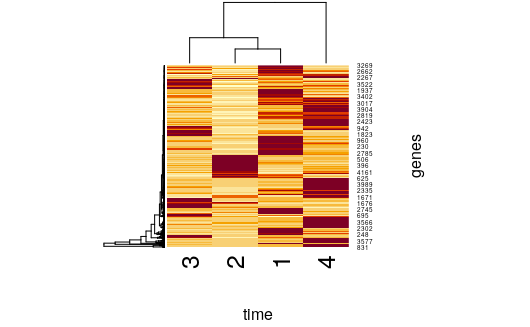

```r
#rownames(counts_matrix) = rownames(significant_genes_30min)
#install.packages("gplots")
#if (!require("RColorBrewer")) {
#install.packages("RColorBrewer")
#}

#library(gplots)
#library(RColorBrewer)
#mypalette = brewer.pal(11,"RdYlBu")
#morecols = colorRampPalette(mypalette)
#mycols=rev(morecols(255))

#column.cols=c("purple","orange")[condition]
#heatmap.2(counts_matrix,trace='none',col=mycols,main='The 100 most significant genes',ColSideColors=column.cols, )

heatmap(counts_matrix, xlab = 'time', ylab = 'genes')
```

Find the matching genes between times

```r
genelist_30min = data.frame(rownames(significant_genes_30min))
colnames(genelist_30min) = "GeneID"

genelist_6h = data.frame(rownames(significant_genes_6h))
colnames(genelist_6h) = "GeneID"

genelist_24h = data.frame(rownames(significant_genes_24h))
colnames(genelist_24h) = "GeneID"


genelist_all = data.frame(intersect(intersect(genelist_24h$GeneID,genelist_6h$GeneID),genelist_30min$GeneID))
```

Download and create Venn diagram

```r
set_30 = as.character(genelist_30min$GeneID)
set_6h = as.character(genelist_6h$GeneID)
set_24h = as.character(genelist_24h$GeneID)

myCol <- brewer.pal(3, "Pastel2")

# Chart
venn.diagram(
        x = list(set_30, set_6h, set_24h),
        category.names = c("30 min" , "6h " , "24h"),
        filename = 'test_venn.png',
        output=TRUE,

        # Output features
        imagetype="png" ,
        height = 480 ,
        width = 480 ,
        resolution = 300,
        compression = "lzw",

        # Circles
        lwd = 2,
        lty = 'blank',
        fill = myCol,

        # Numbers
        cex = .6,
        fontface = "bold",
        fontfamily = "sans",

        # Set names
        cat.cex = 0.6,
        cat.fontface = "bold",
        cat.default.pos = "outer",
        cat.pos = c(-27, 27, 135),
        cat.dist = c(0.055, 0.055, 0.085),
        cat.fontfamily = "sans",
        rotation = 1
)
```

```
[1] 1
```